# Solución Autoevaluación 2024 - Clasificación Pizza/ No Pizza

## Introducción

El objetivo del ejercicio es realizar una **Clasificación de Imágenes (Binaria)** en la que podamos decir si una imagen es un plato de comida de **Pizza o No Pizza**.

La base de datos es un conjunto de imágenes de **Comida de Pizza y No Pizza**.

La base de datos la podréis descargar de esta URL: https://www.dropbox.com/scl/fi/aegle0xuobcqurc5s1b2i/pizzaNopizza.zip?rlkey=semyw2f1eb41jlkm2z91kdw2l&st=blw8ouuo&dl=1

Esta base de datos es una versión **reducida** de la **base de datos de imágenes Food 101** (https://data.vision.ee.ethz.ch/cvl/datasets_extra/food-101/) que recoge 101.000 imágenes de comidas clasificadas en 101 clases diferentes. Para este ejercicio se ha construido una versión con sólo **2 clases**, la clase **Pizza** y la clase **No Pizza**.

Una vez descargada y descomprimida os encontrareis con una **carpeta pizza_not_pizza**, que tendrá ya las **carpetas test, train**. A su vez cada una de estas contendrá las **carpetas pizza y not_pizza**.

A los datos de **test** lo usaremos indistintamente como los datos de **validación**.

El conjunto de datos se reparte de la siguiente manera:

- **Entrenamiento**. Imágenes Pizza: 885
- **Entrenamiento**. Imágenes Not_Pizza: 885
- **Test**. Imágenes Pizza: 98
- **Test**. Imágenes Not_Pizzas: 98

## Información de versiones e Importación de funciones propias

Presentamos información de las versiones usadas de Python y tensorflow, así como la importación de las librerías que se van a usar.

```python
import sys
print("Python version")
print (sys.version)
print("Version info.")
print (sys.version_info)

import tensorflow as tf
print("Tensorflow version")
print(tf.__version__)
```

```
Python version
3.12.4 | packaged by conda-forge | (main, Jun 17 2024, 10:04:44) [MSC v.1940 64 bit (AMD64)]
Version info.
sys.version_info(major=3, minor=12, micro=4, releaselevel='final', serial=0)
Tensorflow version
2.17.0
```

```python
import os
import matplotlib.pyplot as plt
from matplotlib.image import imread
import random
from tensorflow import keras
from tensorflow.keras import layers
from tensorflow.keras import utils
from tensorflow.keras.utils import img_to_array
from tensorflow.keras import applications
from tensorflow.keras.models import Sequential
from sklearn.metrics import confusion_matrix
import numpy as np
import seaborn as sn
import pandas as pd
import matplotlib.pyplot as plt
```

## Carga del dataset

```python
# Función para descargar el dataset y descomprimirlo
def carga_dataset():
    global train_dir
    global test_dir
    import pathlib
    # Definimos la URL para descargar el fichero
    dataset_url = "https://www.dropbox.com/scl/fi/aegle0xuobcqurc5s1b2i/pizzaNopizza.zip?rlkey=semyw2f1eb41jlkm2z91kdw2l&st=blw8ouuo&dl=1"
    # Descargamos el fichero con todas las imágenes y
    # lo desempaquetamos
    global data_dir
    data_dir = tf.keras.utils.get_file(origin=dataset_url,
                                   extract=True)

    data_dir = os.path.dirname(data_dir)

    # Definimos los directorios para usar
    data_dir = data_dir + "\\pizza_not_pizza"
    train_dir = data_dir + "\\train"
    test_dir = data_dir + "\\test"
    print(data_dir)
    print(train_dir)
    print(test_dir)
```

```python
carga_dataset()
```

```
C:\Users\acca3\.keras\datasets\pizza_not_pizza
C:\Users\acca3\.keras\datasets\pizza_not_pizza\train
C:\Users\acca3\.keras\datasets\pizza_not_pizza\test
```

```python
# Definimos el tamaño del batch
# Definimos el tamaño de imagen con la que queremos trabajar
batch_size = 128
img_height = 100
img_width = 100
```

## Creación de los generadores de imágenes

Con los generadores vamos a ser capaces de leer los ficheros desde el sistema de archivos y convertirlos en los datos de entrada de nuestra red neuronal.

```python
# Creamos los generadores de imágenes
# Nos van a permitir leer la imágenes desde los directorios
def crea_generadores_imagenes():
    global train_ds
    global val_ds
    global class_names
    global num_classes
    global ficheros_train_pizza
    global ficheros_train_not_pizza
    global ficheros_test_pizza
    global ficheros_test_not_pizza

    # Creamos el generador para los datos de entrenamiento
    train_ds = tf.keras.utils.image_dataset_from_directory(
      train_dir,
      labels = "inferred",  # Automáticamente etiqueta las imágenes según su directorio
      seed=123,
      image_size=(img_height, img_width),
      batch_size=batch_size)

    # Creamos el generador para los datos de validación
    val_ds = tf.keras.utils.image_dataset_from_directory(
      test_dir,
      labels = "inferred",   # Automáticamente etiqueta las imágenes según su directorio
      seed=123,
      shuffle=False, # !!!!!! Muy importante dejarlo a false para que no baraje cada vez que lo usamos.
      image_size=(img_height, img_width),
      batch_size=batch_size)

    # Obtenemos los nombres de las clases
    class_names = train_ds.class_names

    # Directorios de entrenamiento
    ficheros_train_pizza = os.listdir(train_dir+"\\pizza")
    ficheros_train_not_pizza = os.listdir(train_dir+"\\not_pizza")
    ficheros_test_pizza = os.listdir(test_dir+"\\pizza")
    ficheros_test_not_pizza = os.listdir(test_dir+"\\not_pizza")
    num_classes = 2
```

```python
crea_generadores_imagenes()
```

```
Found 1770 files belonging to 2 classes.
Found 196 files belonging to 2 classes.
```

## Visualización de imágenes aleatorias

```python
# Función para visualizar imágenes aleatorias (5 de cada clase) de entrenamiento
def visualiza_imagenes_random():

    # Mostramos los elementos de la clase 0 ( No Pizza )
    plt.figure(figsize=(10, 10))
    # Obtenemos las imágenes y sus etiquetas para la clase No Pizza
    for images, labels in train_ds.map(lambda x, y:  (x[y==0], y[y==0])): # Nos quedamos sólo con los datos de la clase 0
      for i in range(5):
        ax = plt.subplot(1, 5, i + 1)
        plt.imshow(images[i].numpy().astype("uint8"))
        plt.axis("off")

    # Obtenemos las imágenes y sus etiquetas para la clase Pizza
    # Mostramos los elementos de la clase 1 ( Pizza )
    plt.figure(figsize=(10, 10))
    for images, labels in train_ds.map(lambda x, y:  (x[y==1], y[y==1])):  # Nos quedamos sólo con los datos de la clase 1
      for i in range(5):
        ax = plt.subplot(1, 5, i + 1)
        plt.imshow(images[i].numpy().astype("uint8"))
        plt.axis("off")
```

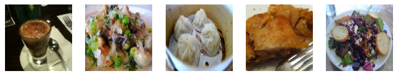

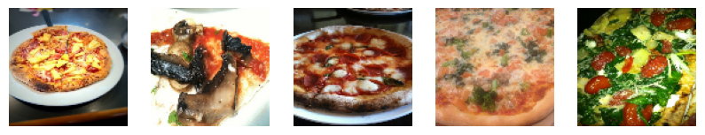

```python
visualiza_imagenes_random()
```

## Modelo 1

### Creamos el modelo

```python
# Función para la creación del modelo 1
def crea_modelo_1():
    # Creamos el modelo
    # Capa de entrada formato 100x100 pixels y 3 canales de color RGB
    inputs = keras.Input(shape=(img_width, img_height, 3))

    # Dividimos entre 255 para "normalizar" el dato y dejarlo entre 0 y 1
    x = layers.Rescaling(1.0/255)(inputs)

    # Añadimos capa de convolución con 32 filtros de tamaño 3 y activación relu
    x = layers.Conv2D(filters=32, kernel_size=3, activation="relu")(x)
    # Añadimos capa de pooling, tipo max y de tamaño 2
    x = layers.MaxPooling2D(pool_size=2)(x)

    # Aplanamos los datos
    x = layers.Flatten()(x)

    # Ponemos la capa de dropout con 0.3
    x = layers.Dropout(0.3)(x)

    # Ponemos una capa densamente conectada
    x = layers.Dense(128, activation="relu")(x)

    # La salida la hacemos de tipo softmax con 5 neuronas (números de clases diferentes)
    outputs = layers.Dense(1, activation="sigmoid")(x)

    # Construimos el modelo de la Red Neuronal Convolucional
    model = keras.Model(inputs=inputs, outputs=outputs)

    model.compile(optimizer="adam",
        loss="binary_crossentropy",
        metrics=["accuracy"])

    model.summary()
    return model
```

```python
modelo_1 = crea_modelo_1()
```

```
Model: "functional"
```

```
┏━━━━━━━━━━━━━━━━━━━━━━━━━━━━━━━━━━━━━━┳━━━━━━━━━━━━━━━━━━━━━━━━━━━━━┳━━━━━━━━━━━━━━━━━┓
┃ Layer (type)                         ┃ Output Shape                ┃         Param # ┃
┡━━━━━━━━━━━━━━━━━━━━━━━━━━━━━━━━━━━━━━╇━━━━━━━━━━━━━━━━━━━━━━━━━━━━━╇━━━━━━━━━━━━━━━━━┩
│ input_layer (InputLayer)             │ (None, 100, 100, 3)         │               0 │
├──────────────────────────────────────┼─────────────────────────────┼─────────────────┤
│ rescaling (Rescaling)                │ (None, 100, 100, 3)         │               0 │
├──────────────────────────────────────┼─────────────────────────────┼─────────────────┤
│ conv2d (Conv2D)                      │ (None, 98, 98, 32)          │             896 │
├──────────────────────────────────────┼─────────────────────────────┼─────────────────┤
│ max_pooling2d (MaxPooling2D)         │ (None, 49, 49, 32)          │               0 │
├──────────────────────────────────────┼─────────────────────────────┼─────────────────┤
│ flatten (Flatten)                    │ (None, 76832)               │               0 │
├──────────────────────────────────────┼─────────────────────────────┼─────────────────┤
│ dropout (Dropout)                    │ (None, 76832)               │               0 │
├──────────────────────────────────────┼─────────────────────────────┼─────────────────┤
│ dense (Dense)                        │ (None, 128)                 │       9,834,624 │
├──────────────────────────────────────┼─────────────────────────────┼─────────────────┤
│ dense_1 (Dense)                      │ (None, 1)                   │             129 │
└──────────────────────────────────────┴─────────────────────────────┴─────────────────┘
```

```
 Total params: 9,835,649 (37.52 MB)
```

```
 Trainable params: 9,835,649 (37.52 MB)
```

```
 Non-trainable params: 0 (0.00 B)
```

### Entrenamos el modelo

```python
# Función que entrena el modelo que le pasemos
# Le asignamos el flujo de entrada de entranamiento y validación
# Ponemos 10 iteraciones
def entrena_modelo(modelo,epocas):
  # Ejecutamos el entrenamiento
  # guardando el histórico de la
  # función de pérdida y la métrica
  history = modelo.fit(
    train_ds,
    epochs = epocas,
    validation_data = val_ds )
  return history
```

```python
history_1 = entrena_modelo(modelo_1,20)
```

```
14/14 ━━━━━━━━━━━━━━━━━━━━ 3s 131ms/step - accuracy: 0.4945 - loss: 2.9081 - val_accuracy: 0.5102 - val_loss: 0.6929
14/14 ━━━━━━━━━━━━━━━━━━━━ 2s 124ms/step - accuracy: 0.5786 - loss: 0.6829 - val_accuracy: 0.5816 - val_loss: 0.6757
14/14 ━━━━━━━━━━━━━━━━━━━━ 2s 132ms/step - accuracy: 0.6099 - loss: 0.6669 - val_accuracy: 0.6429 - val_loss: 0.6643
14/14 ━━━━━━━━━━━━━━━━━━━━ 2s 130ms/step - accuracy: 0.6442 - loss: 0.6483 - val_accuracy: 0.6531 - val_loss: 0.6559
14/14 ━━━━━━━━━━━━━━━━━━━━ 2s 127ms/step - accuracy: 0.6629 - loss: 0.6326 - val_accuracy: 0.6939 - val_loss: 0.6511
14/14 ━━━━━━━━━━━━━━━━━━━━ 2s 128ms/step - accuracy: 0.7086 - loss: 0.5963 - val_accuracy: 0.6786 - val_loss: 0.6265
14/14 ━━━━━━━━━━━━━━━━━━━━ 2s 130ms/step - accuracy: 0.7215 - loss: 0.5463 - val_accuracy: 0.6582 - val_loss: 0.6252
14/14 ━━━━━━━━━━━━━━━━━━━━ 2s 129ms/step - accuracy: 0.7523 - loss: 0.5015 - val_accuracy: 0.7245 - val_loss: 0.5770
14/14 ━━━━━━━━━━━━━━━━━━━━ 2s 129ms/step - accuracy: 0.8068 - loss: 0.4632 - val_accuracy: 0.7143 - val_loss: 0.5756
14/14 ━━━━━━━━━━━━━━━━━━━━ 2s 129ms/step - accuracy: 0.8299 - loss: 0.4263 - val_accuracy: 0.7347 - val_loss: 0.5667
14/14 ━━━━━━━━━━━━━━━━━━━━ 2s 129ms/step - accuracy: 0.8303 - loss: 0.4153 - val_accuracy: 0.7296 - val_loss: 0.5670
14/14 ━━━━━━━━━━━━━━━━━━━━ 2s 129ms/step - accuracy: 0.8693 - loss: 0.3650 - val_accuracy: 0.7143 - val_loss: 0.5606
14/14 ━━━━━━━━━━━━━━━━━━━━ 2s 128ms/step - accuracy: 0.8811 - loss: 0.3500 - val_accuracy: 0.7296 - val_loss: 0.5983
14/14 ━━━━━━━━━━━━━━━━━━━━ 2s 138ms/step - accuracy: 0.8760 - loss: 0.3308 - val_accuracy: 0.7296 - val_loss: 0.5616
14/14 ━━━━━━━━━━━━━━━━━━━━ 2s 138ms/step - accuracy: 0.9224 - loss: 0.2766 - val_accuracy: 0.7245 - val_loss: 0.5777
14/14 ━━━━━━━━━━━━━━━━━━━━ 2s 136ms/step - accuracy: 0.9168 - loss: 0.2676 - val_accuracy: 0.7347 - val_loss: 0.5890
14/14 ━━━━━━━━━━━━━━━━━━━━ 2s 125ms/step - accuracy: 0.9310 - loss: 0.2335 - val_accuracy: 0.7347 - val_loss: 0.5933
14/14 ━━━━━━━━━━━━━━━━━━━━ 2s 127ms/step - accuracy: 0.9407 - loss: 0.2124 - val_accuracy: 0.6990 - val_loss: 0.6217
14/14 ━━━━━━━━━━━━━━━━━━━━ 2s 125ms/step - accuracy: 0.9456 - loss: 0.1880 - val_accuracy: 0.7296 - val_loss: 0.6091
14/14 ━━━━━━━━━━━━━━━━━━━━ 2s 129ms/step - accuracy: 0.9595 - loss: 0.1719 - val_accuracy: 0.7194 - val_loss: 0.6982
```

### Visualizamos el historico del entrenamiento del modelo

```python
# Mostramos las gráficas de histórico de entrenamiento
# de la función de pérdida y la métrica de entrenamiento y validación
def muestra_historico_entrenamiento(history, epocas):
  acc = history.history['accuracy']
  val_acc = history.history['val_accuracy']

  loss=history.history['loss']
  val_loss=history.history['val_loss']

  epochs_range = range(epocas)

  plt.figure(figsize=(8, 8))
  plt.subplot(1, 2, 1)
  plt.plot(epochs_range, acc, label='Training Accuracy')
  plt.plot(epochs_range, val_acc, label='Validation Accuracy')
  plt.legend(loc='lower right')
  plt.title('Training and Validation Accuracy')

  plt.subplot(1, 2, 2)
  plt.plot(epochs_range, loss, label='Training Loss')
  plt.plot(epochs_range, val_loss, label='Validation Loss')
  plt.legend(loc='upper right')
  plt.title('Training and Validation Loss')
  plt.show()
```

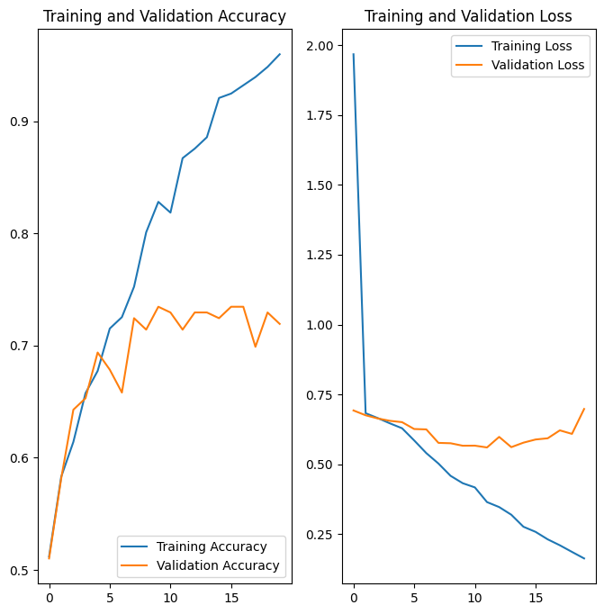

```python
muestra_historico_entrenamiento(history_1,20)
```

## Modelo 2

En este modelo vamos a tener:

- Capa **convolución** con 32 filtros, tamaño 3x3 y activación relu
- Capa de **pooling** tipo maxpooling de tamaño 2x2
- Capa **convolución** con 64 filtros, tamaño 3x3 y activación relu
- Capa de **pooling** tipo maxpooling de tamaño 2x2
- Capa **convolución** con 64 filtros, tamaño 3x3 y activación relu
- Capa de **pooling** tipo maxpooling de tamaño 2x2
- Capa para **aplanar** la información
- Capa de **dropout** al 0.3
- Capa **dénsamente conectada** de 256 neuronas y activación relu
- Capa **dénsamente conectada** de 64 neuronas y activación relu
- Capa de **salida de** 1 neurona y activación **sigmoid** que nos da la clasificación binaria

### Creamos el modelo

```python
# Función para la creación del modelo 1
def crea_modelo_2():
    # Creamos el modelo
    # Capa de entrada formato 180x180 pixels y 3 canales de color RGB
    inputs = keras.Input(shape=(img_width, img_height, 3))

    # Dividimos entre 255 para "normalizar" el dato y dejarlo entre 0 7 1
    x = layers.Rescaling(1./255)(inputs)

    # Añadimos capa de convolución con 32 filtros de tamaño 3 y activación relu
    x = layers.Conv2D(filters=32, kernel_size=3, activation="relu")(x)
    # Añadimos capa de pooling, tipo max y de tamaño 2
    x = layers.MaxPooling2D(pool_size=2)(x)
    x = layers.Conv2D(filters=64, kernel_size=3, activation="relu")(x)
    # Añadimos capa de pooling, tipo max y de tamaño 2
    x = layers.MaxPooling2D(pool_size=2)(x)
    x = layers.Conv2D(filters=64, kernel_size=3, activation="relu")(x)
    # Añadimos capa de pooling, tipo max y de tamaño 2
    x = layers.MaxPooling2D(pool_size=2)(x)

    # Aplanamos los datos
    x = layers.Flatten()(x)

    # Ponemos la capa de dropout con 0.3
    x = layers.Dropout(0.3)(x)

    # Ponemos una capa densamente conectada
    x = layers.Dense(256, activation="relu")(x)

    # Ponemos una capa densamente conectada
    x = layers.Dense(64, activation="relu")(x)

    # La salida la hacemos de tipo softmax con 5 neuronas (números de clases diferentes)
    outputs = layers.Dense(1, activation="sigmoid")(x)

    # Construimos el modelo de la Red Neuronal Convolucional
    model = keras.Model(inputs=inputs, outputs=outputs)

    model.compile(optimizer="adam",
        loss="binary_crossentropy",
        metrics=["accuracy"])

    model.summary()
    return model
```

```python
modelo_2 = crea_modelo_2()
```

```
Model: "functional_2"
```

```
┏━━━━━━━━━━━━━━━━━━━━━━━━━━━━━━━━━━━━━━┳━━━━━━━━━━━━━━━━━━━━━━━━━━━━━┳━━━━━━━━━━━━━━━━━┓
┃ Layer (type)                         ┃ Output Shape                ┃         Param # ┃
┡━━━━━━━━━━━━━━━━━━━━━━━━━━━━━━━━━━━━━━╇━━━━━━━━━━━━━━━━━━━━━━━━━━━━━╇━━━━━━━━━━━━━━━━━┩
│ input_layer_2 (InputLayer)           │ (None, 100, 100, 3)         │               0 │
├──────────────────────────────────────┼─────────────────────────────┼─────────────────┤
│ rescaling_2 (Rescaling)              │ (None, 100, 100, 3)         │               0 │
├──────────────────────────────────────┼─────────────────────────────┼─────────────────┤
│ conv2d_4 (Conv2D)                    │ (None, 98, 98, 32)          │             896 │
├──────────────────────────────────────┼─────────────────────────────┼─────────────────┤
│ max_pooling2d_4 (MaxPooling2D)       │ (None, 49, 49, 32)          │               0 │
├──────────────────────────────────────┼─────────────────────────────┼─────────────────┤
│ conv2d_5 (Conv2D)                    │ (None, 47, 47, 64)          │          18,496 │
├──────────────────────────────────────┼─────────────────────────────┼─────────────────┤
│ max_pooling2d_5 (MaxPooling2D)       │ (None, 23, 23, 64)          │               0 │
├──────────────────────────────────────┼─────────────────────────────┼─────────────────┤
│ conv2d_6 (Conv2D)                    │ (None, 21, 21, 64)          │          36,928 │
├──────────────────────────────────────┼─────────────────────────────┼─────────────────┤
│ max_pooling2d_6 (MaxPooling2D)       │ (None, 10, 10, 64)          │               0 │
├──────────────────────────────────────┼─────────────────────────────┼─────────────────┤
│ flatten_2 (Flatten)                  │ (None, 6400)                │               0 │
├──────────────────────────────────────┼─────────────────────────────┼─────────────────┤
│ dropout_2 (Dropout)                  │ (None, 6400)                │               0 │
├──────────────────────────────────────┼─────────────────────────────┼─────────────────┤
│ dense_5 (Dense)                      │ (None, 256)                 │       1,638,656 │
├──────────────────────────────────────┼─────────────────────────────┼─────────────────┤
│ dense_6 (Dense)                      │ (None, 64)                  │          16,448 │
├──────────────────────────────────────┼─────────────────────────────┼─────────────────┤
│ dense_7 (Dense)                      │ (None, 1)                   │              65 │
└──────────────────────────────────────┴─────────────────────────────┴─────────────────┘
```

```
 Total params: 1,711,489 (6.53 MB)
```

```
 Trainable params: 1,711,489 (6.53 MB)
```

```
 Non-trainable params: 0 (0.00 B)
```

### Entrenamos el modelo

```python
history_2 = entrena_modelo(modelo_2,20)
```

```
14/14 ━━━━━━━━━━━━━━━━━━━━ 4s 156ms/step - accuracy: 0.5235 - loss: 0.7165 - val_accuracy: 0.6327 - val_loss: 0.6621
14/14 ━━━━━━━━━━━━━━━━━━━━ 2s 143ms/step - accuracy: 0.6623 - loss: 0.6424 - val_accuracy: 0.5561 - val_loss: 0.7011
14/14 ━━━━━━━━━━━━━━━━━━━━ 2s 148ms/step - accuracy: 0.6713 - loss: 0.5896 - val_accuracy: 0.7194 - val_loss: 0.5702
14/14 ━━━━━━━━━━━━━━━━━━━━ 2s 161ms/step - accuracy: 0.7386 - loss: 0.5294 - val_accuracy: 0.7602 - val_loss: 0.5828
14/14 ━━━━━━━━━━━━━━━━━━━━ 2s 152ms/step - accuracy: 0.7573 - loss: 0.5003 - val_accuracy: 0.7500 - val_loss: 0.5422
14/14 ━━━━━━━━━━━━━━━━━━━━ 2s 146ms/step - accuracy: 0.7799 - loss: 0.4692 - val_accuracy: 0.7449 - val_loss: 0.5450
14/14 ━━━━━━━━━━━━━━━━━━━━ 2s 149ms/step - accuracy: 0.7725 - loss: 0.4708 - val_accuracy: 0.6939 - val_loss: 0.6363
14/14 ━━━━━━━━━━━━━━━━━━━━ 2s 145ms/step - accuracy: 0.7592 - loss: 0.4951 - val_accuracy: 0.7704 - val_loss: 0.5263
14/14 ━━━━━━━━━━━━━━━━━━━━ 2s 146ms/step - accuracy: 0.8285 - loss: 0.4240 - val_accuracy: 0.7602 - val_loss: 0.5460
14/14 ━━━━━━━━━━━━━━━━━━━━ 2s 148ms/step - accuracy: 0.8116 - loss: 0.4075 - val_accuracy: 0.7806 - val_loss: 0.5431
14/14 ━━━━━━━━━━━━━━━━━━━━ 2s 152ms/step - accuracy: 0.8212 - loss: 0.3978 - val_accuracy: 0.7194 - val_loss: 0.6128
14/14 ━━━━━━━━━━━━━━━━━━━━ 2s 148ms/step - accuracy: 0.8036 - loss: 0.4300 - val_accuracy: 0.7857 - val_loss: 0.4964
14/14 ━━━━━━━━━━━━━━━━━━━━ 2s 148ms/step - accuracy: 0.8558 - loss: 0.3496 - val_accuracy: 0.7908 - val_loss: 0.5564
14/14 ━━━━━━━━━━━━━━━━━━━━ 2s 152ms/step - accuracy: 0.8764 - loss: 0.3037 - val_accuracy: 0.7806 - val_loss: 0.5437
14/14 ━━━━━━━━━━━━━━━━━━━━ 2s 151ms/step - accuracy: 0.8776 - loss: 0.3072 - val_accuracy: 0.7602 - val_loss: 0.6573
14/14 ━━━━━━━━━━━━━━━━━━━━ 2s 145ms/step - accuracy: 0.8629 - loss: 0.3118 - val_accuracy: 0.8010 - val_loss: 0.5712
14/14 ━━━━━━━━━━━━━━━━━━━━ 2s 146ms/step - accuracy: 0.8982 - loss: 0.2443 - val_accuracy: 0.8010 - val_loss: 0.5875
14/14 ━━━━━━━━━━━━━━━━━━━━ 2s 148ms/step - accuracy: 0.9200 - loss: 0.2086 - val_accuracy: 0.7398 - val_loss: 0.7172
14/14 ━━━━━━━━━━━━━━━━━━━━ 2s 149ms/step - accuracy: 0.8936 - loss: 0.2464 - val_accuracy: 0.7755 - val_loss: 0.7086
14/14 ━━━━━━━━━━━━━━━━━━━━ 2s 145ms/step - accuracy: 0.9096 - loss: 0.2141 - val_accuracy: 0.7602 - val_loss: 0.6657
```

### Mostramos el histórico del entrenamiento

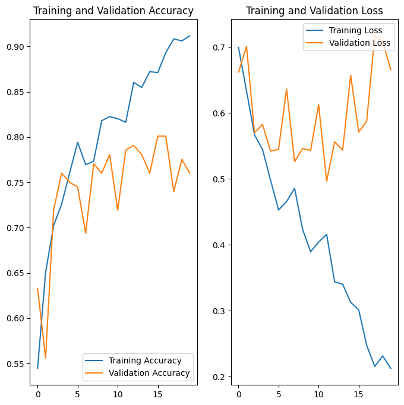

```python
muestra_historico_entrenamiento(history_2,20)
```

## Matriz de Confusión mejor modelo

Mostramos la matriz de confusión para los datos de test del modelo cargado.

Lo primero que tenemos que hacer es elegir el modelo, para eso vamos a visulizar los valores de entrenamiento y validación.

```python
loss_1_train, accuracy_1_train = modelo_1.evaluate(train_ds,verbose = 0)
loss_1_val, accuracy_1_val = modelo_1.evaluate(val_ds,verbose = 0)
loss_2_train, accuracy_2_train = modelo_2.evaluate(train_ds,verbose = 0)
loss_2_val, accuracy_2_val = modelo_2.evaluate(val_ds,verbose = 0)
print(f"Modelo 1 Train accuracy: {accuracy_1_train:.3f}")
print(f"Modelo 1 Train loss: {loss_1_train:.3f}")
print(f"Modelo 1 Val accuracy: {accuracy_1_val:.3f}")
print(f"Modelo 1 Val loss: {loss_2_train:.3f}")

print(f"Modelo 2 Train accuracy: {accuracy_2_train:.3f}")
print(f"Modelo 2 Train loss: {loss_2_train:.3f}")
print(f"Modelo 2 Val accuracy: {accuracy_2_val:.3f}")
print(f"Modelo 2 Val loss: {loss_2_val:.3f}")
```

```
Modelo 1 Train accuracy: 0.938
Modelo 1 Train loss: 0.191
Modelo 1 Val accuracy: 0.719
Modelo 1 Val loss: 0.172
Modelo 2 Train accuracy: 0.945
Modelo 2 Train loss: 0.172
Modelo 2 Val accuracy: 0.760
Modelo 2 Val loss: 0.666
```

Elegimos el **Modelo 2** ya que es capaz de generalizar mejor que el Modelo 1.

```python
# Creamos la matriz de confusión con los datos de test
def matriz_confusion(modelo):

  predicciones = modelo.predict( val_ds, verbose = 0 )


  # Obtenemos las predicciones como Clasificación Multiclase
  # predicciones = np.argmax(predicciones, axis=-1)

  # Obtenemos las predicciones como Clasificación Binaria
  predicciones[predicciones <= 0.5] = 0
  predicciones[predicciones > 0.5] = 1


  class_names = ['not_pizza', 'pizza']

  # Obtenemos las etiquetas de los datos de validación
  val_labels = tf.concat([y for x, y in val_ds], axis=0)

  #Construimos el dataframe con la matriz de confusión de los valores reales y las predicciones
  df_cm = pd.DataFrame(confusion_matrix(predicciones,val_labels))

  # Mostramos el gráfico de la matriz de confusión
  sn.set(font_scale=1.4) # for label size
  sn.heatmap(df_cm, cmap='Blues', annot=True, annot_kws={"size": 16}) # font size

  plt.show()
```

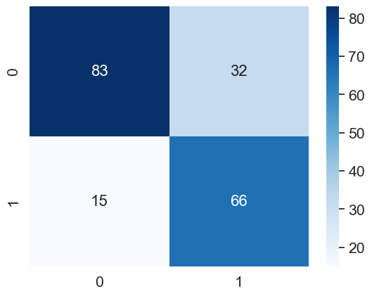

```python
matriz_confusion(modelo_2)
```

## Visualización predicciones en test

```python
# Función para visualizar imágenes aleatorias (5 de cada clase) de test
# Tenemos que poner el texto de la clase que se predice
def visualiza_imagenes_random_test(modelo):

    plt.figure(figsize=(10, 10))
    # Obtenemos las imágenes y sus etiquetas para la clase No Pizza
    val_ds_nopizza = val_ds.map(lambda x, y:  (x[y==0], y[y==0]))  # Nos quedamos sólo con los datos de la clase 0
    images, labels  = next(iter(val_ds_nopizza))

    predicciones = modelo.predict( images, verbose = 0 )
    # Obtenemos las predicciones como Clasificación Binaria
    predicciones[predicciones <= 0.5] = 0
    predicciones[predicciones > 0.5] = 1
    predicciones = predicciones.astype(int)
    for i in range(5):
        ax = plt.subplot(1, 5, i + 1)
        plt.imshow(images[i].numpy().astype("uint8"))
        plt.title("No Pizza" if predicciones[i]==0 else "Pizza")
        plt.axis("off")

    plt.figure(figsize=(10, 10))
    # Obtenemos las imágenes y sus etiquetas para la clase Pizza
    val_ds_pizza = val_ds.map(lambda x, y:  (x[y==1], y[y==1]))  # Nos quedamos sólo con los datos de la clase 1
    images, labels  = next(iter(val_ds_pizza))

    predicciones = modelo.predict( images, verbose = 0 )
    # Obtenemos las predicciones como Clasificación Binaria
    predicciones[predicciones <= 0.5] = 0
    predicciones[predicciones > 0.5] = 1
    predicciones = predicciones.astype(int)
    for i in range(5):
        ax = plt.subplot(1, 5, i + 1)
        plt.imshow(images[i].numpy().astype("uint8"))
        plt.title("No Pizza" if predicciones[i]==0 else "Pizza")
        plt.axis("off")
```

[figure not shown]

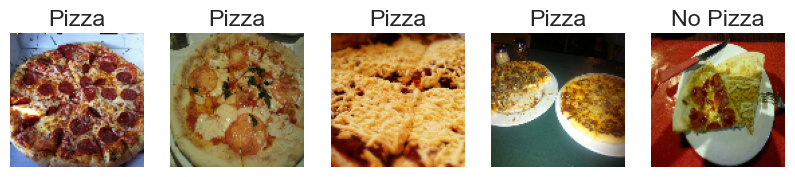

```python
visualiza_imagenes_random_test(modelo_2)
```